# EDA of Pennsylvania School Assessments 2015-2016 by Barry Davis

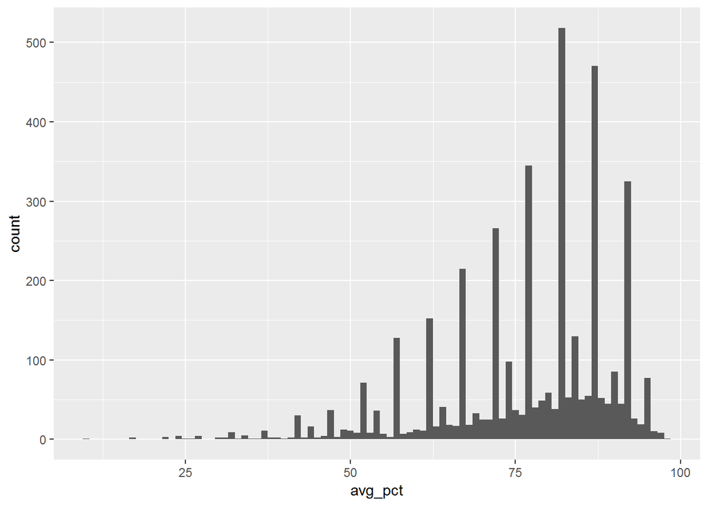

```r
# Distribution of average scores
ggplot(pa.math, aes(x=avg_pct)) +
  geom_histogram(binwidth=1)
```

```r
summary(pa.math$avg_pct)
```

```
##    Min. 1st Qu.  Median    Mean 3rd Qu.    Max.    NA's
##   10.00   70.00   81.00   76.85   87.00   98.00       2
```

The above scores aren’t grouped by grade, so these numbers represent all scores of all grades from all school districts in Pennsylvania.

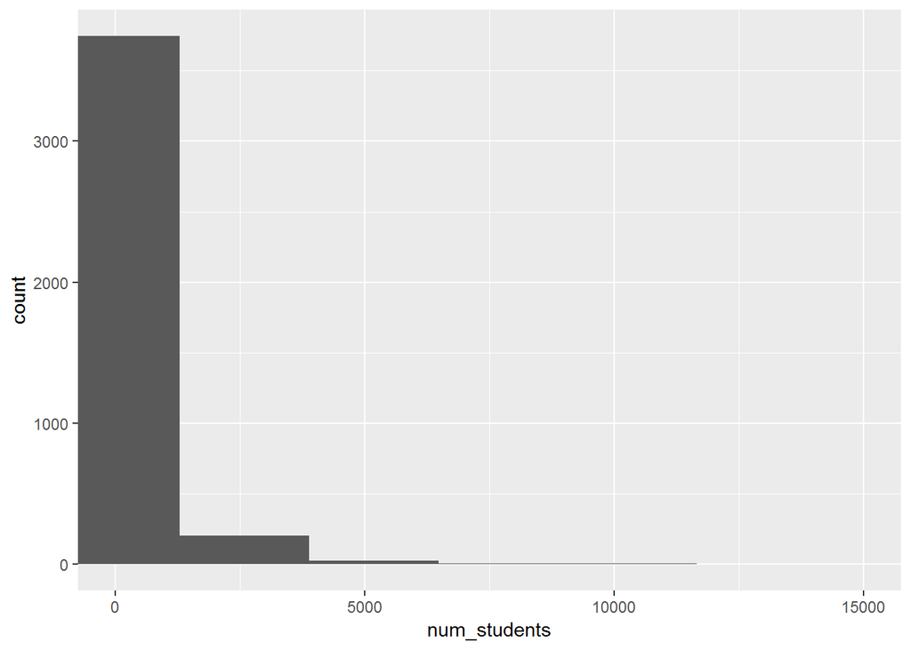

```r
# Distribution of number of students
ggplot(pa.math, aes(x=num_students)) +
  geom_histogram() +
  coord_cartesian(xlim=c(0,15000))
```

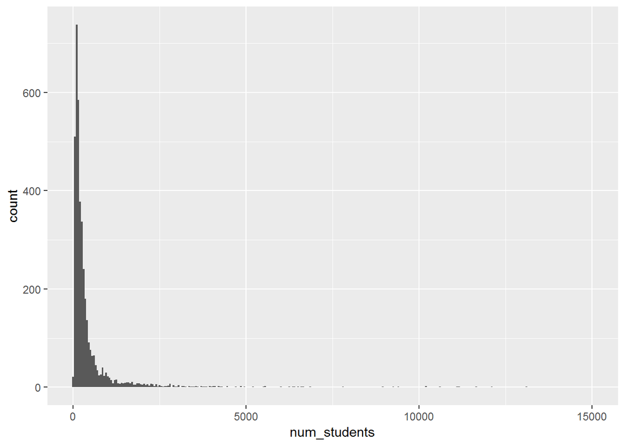

```r
# Better bins
ggplot(pa.math, aes(x=num_students)) +
  geom_histogram(binwidth=50) +
  coord_cartesian(xlim=c(0,15000))
```

I plotted the second graph to get a better insight into the distribution of those schools with under 5000 students. Most are well under 1200.

# Univariate Analysis

### What is the structure of your dataset?

There are 499 school districts. Each district has 8 grade levels that were tested, giving us 3992 total rows or observations. The variable grade is a factor with the following levels: * all, eighth, fifth, fourth, high school, seventh, sixth, third

### What is/are the main feature(s) of interest in your dataset?

The main features here are average percent proficiency and grade.

### What other features in the dataset do you think will help support your investigation into your feature(s) of interest?

I believe district will be a factor in scores. I think we will see scores that are consistent within a district.

### Did you create any new variables from existing variables in the dataset?

I created the grade, low, high, num_students, and avg_pct variables. The grade and num_students were created by reshaping the data and condensing the columns into row values. Some of these scores were ranges, so I split the range into a low and high score, then calculated the range average for avg_pct.

### Of the features you investigated, were there any unusual distributions? Did you perform any operations on the data to tidy, adjust, or change the form of the data? If so, why did you do this?

The number of students distribution was skewed to the right as a few schools had a very large number of students. I created a second plot of that distribution to get a better look at the number of students in districts under 5000 students.

# Bivariate Plots Section

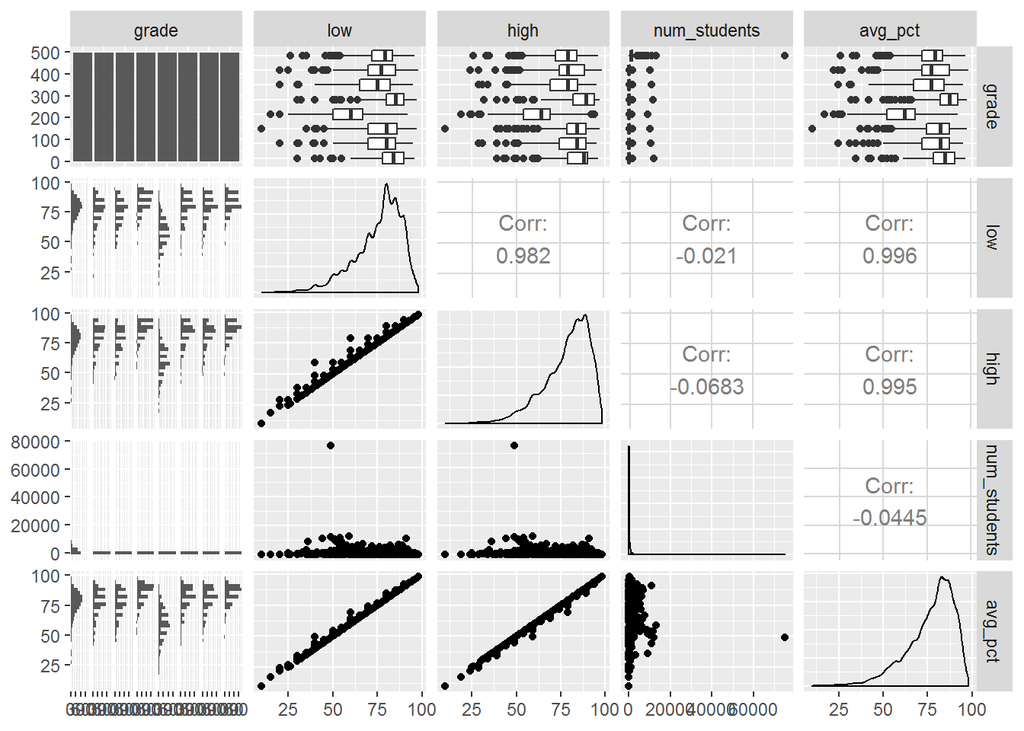

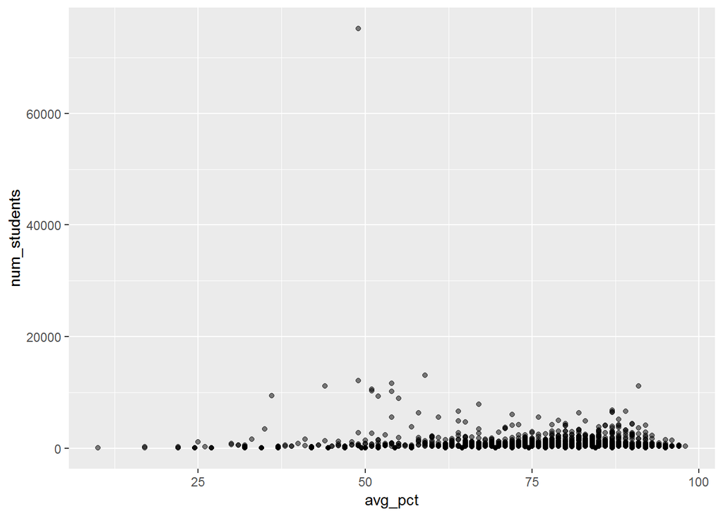

```r
# Do we see any pattern from 5000ft view?
ggplot(pa.math, aes(x=avg_pct, y=num_students)) +
  geom_point(alpha=.5)
```

Let’s remove the outlier and get a better look.

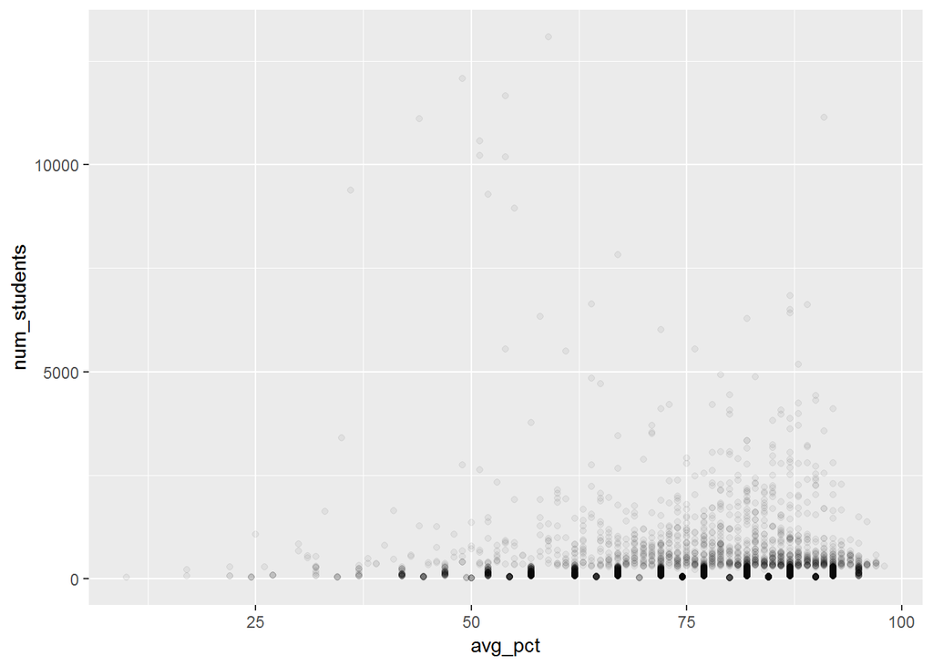

```r
# Same plot, removed outlier
ggplot(subset(pa.math, num_students < 60000), aes(x=avg_pct, y=num_students)) +
  geom_point(alpha=1/20)
```

So it doesn’t appear there’s a correlation with number of students and average proficiency, but let’s take a look by grade to make sure there aren’t underlying patterns.

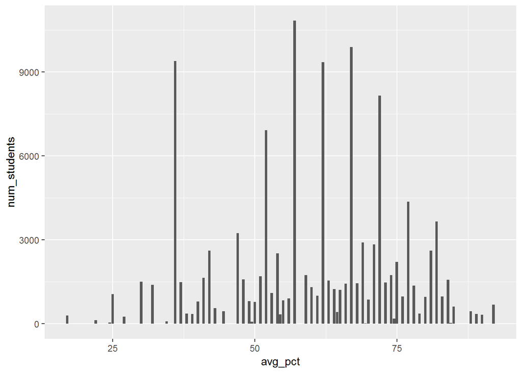

```r
# Size for high schools
ggplot(pa.math %>% filter(grade=="high school"), aes(x=avg_pct, y=num_students)) +
  geom_col()
```

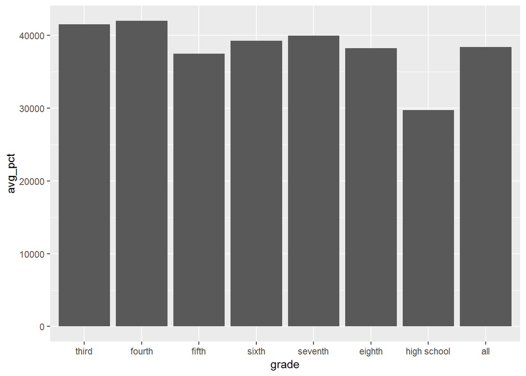

```r
# Size for high schools
ggplot(pa.math, aes(x=grade, y=avg_pct)) +
  geom_col() +
  scale_x_discrete(limits = c("third", "fourth", "fifth", "sixth", "seventh", "eighth", "high school", "all"))
```

# Bivariate Analysis

### Talk about some of the relationships you observed in this part of the investigation. How did the feature(s) of interest vary with other features in the dataset?

The set only has limited features, there was no variation.

### Did you observe any interesting relationships between the other features (not the main feature(s) of interest)?

There weren’t many features outside of the main ones to be used.

### What was the strongest relationship you found?

There was no great relationship, so the strongest was number of students. However, this was not a good indicator of proficiency.

# Multivariate Plots Section

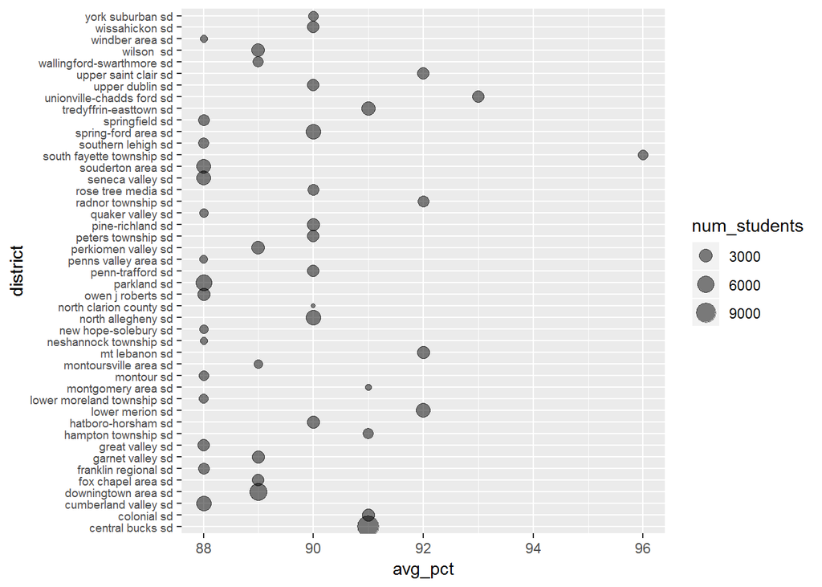

```r
# Let's see the top 25% districts overall, and look for correlations in number
# of students and scores
p <- pa.math %>% filter(grade=="all", avg_pct > quantile(pa.math$avg_pct,
                                                         probs=.75, na.rm=TRUE))
ggplot(p, aes(x=district, y=avg_pct, size=num_students)) +
  geom_point(alpha=.5) +
  theme(axis.text.y = element_text(size=7)) +
  coord_flip()
```

This is the top 25% for overall proficiency average. The number of students, or size of the school doesn’t seem to correlate well with average proficiency for the top schools.

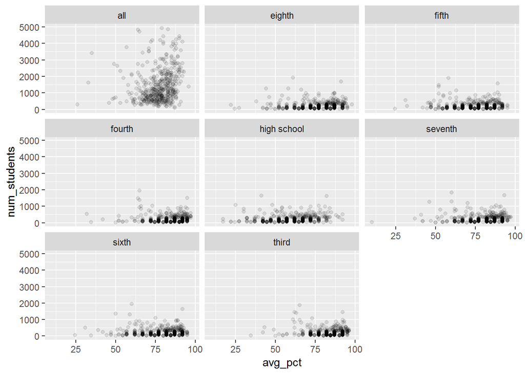

```r
# Let's see this by grade level, filtering down even further to less than 5000
# students
p <- pa.math %>% filter(num_students < 5000, !is.na(avg_pct))
ggplot(p, aes(x=avg_pct, y=num_students)) +
  geom_point(alpha=1/10) +
  facet_wrap(~grade)
```

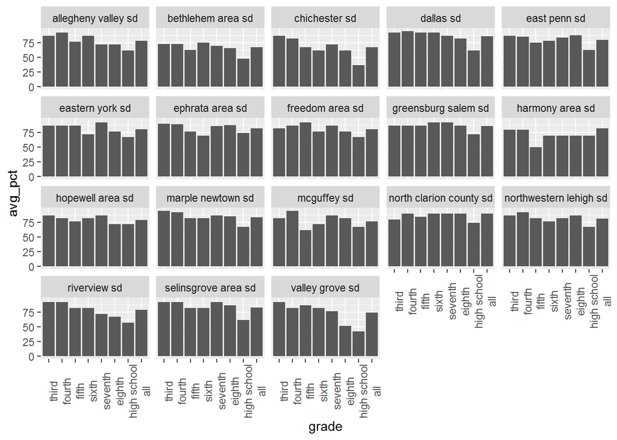

```r
# Random sample to look for any patterns by district and grade level
set.seed(1979)
sampleDistricts <- sample(pa.math$district, 20, replace=FALSE)
pa.math.samp <- pa.math %>% filter(district %in% sampleDistricts)
ggplot(pa.math.samp, aes(x=grade, y=avg_pct)) +
  geom_col() +
  facet_wrap(~district) +
  scale_x_discrete(limits = c("third", "fourth", "fifth", "sixth", "seventh",
                              "eighth", "high school", "all")) +
  theme(axis.text.x = element_text(angle=90))
```

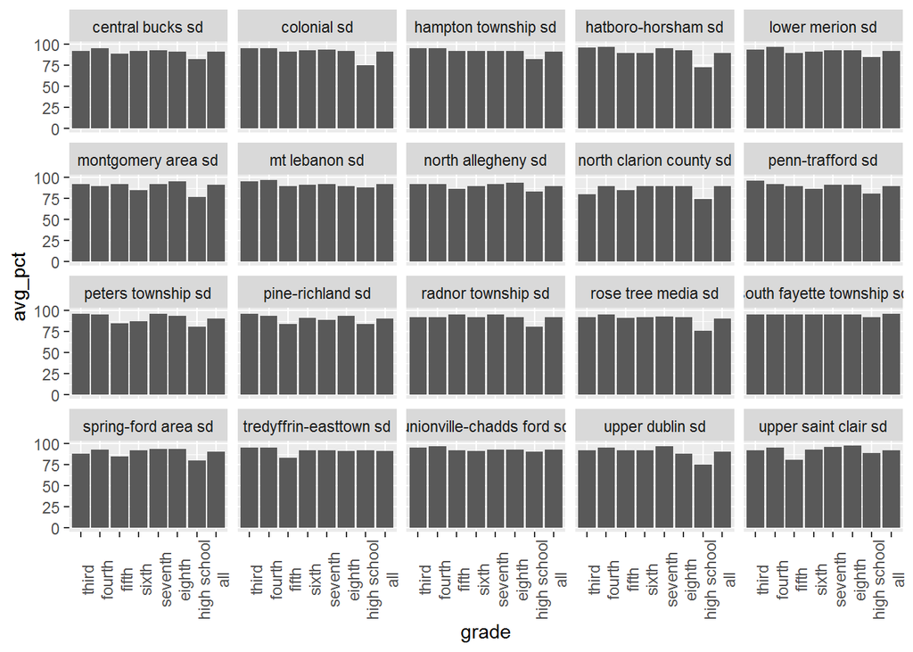

```r
# What about the top 20 overall schools?
top20 <- pa.math %>% filter(grade=="all") %>%
  arrange(desc(avg_pct)) %>% head(20)
p <- pa.math %>% filter(district %in% top20$district)
ggplot(p, aes(x=grade, y=avg_pct)) +
  geom_col() +
  facet_wrap(~district) +
  scale_x_discrete(limits = c("third", "fourth", "fifth", "sixth", "seventh",
                              "eighth", "high school", "all")) +
  theme(axis.text.x = element_text(angle=90))
```

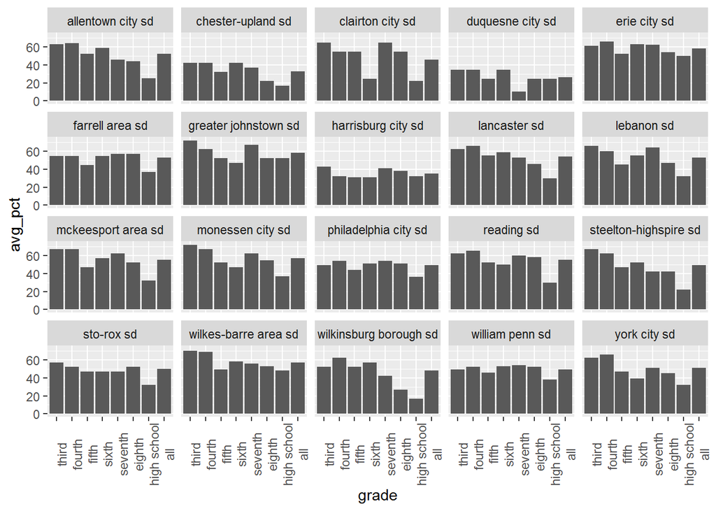

```r
# Bottom 20 schools
bottom20 <- pa.math %>% filter(grade=="all") %>% arrange(avg_pct) %>% head(20)
p <- pa.math %>% filter(district %in% bottom20$district)
ggplot(p, aes(x=grade, y=avg_pct)) +
  geom_col() +
  facet_wrap(~district) +
  scale_x_discrete(limits = c("third", "fourth", "fifth", "sixth", "seventh", "eighth", "high school", "all")) +
  theme(axis.text.x = element_text(angle=90))
```

# Multivariate Analysis

### Talk about some of the relationships you observed in this part of the investigation. Were there features that strengthened each other in terms of looking at your feature(s) of interest?

The proficiency throughout each grade in a given district varies from school to school. There seems to be a dip in the high school scores, which could be due to a larger student base compared to each individual grade, the variety of math being taught (and understood), and the length of time since using the math skills that are assessed. We would need to know more about the assessment.

### Were there any interesting or surprising interactions between features?

No, these were fairly expected. I did think each district would have more consistency from grade to grade. The top 20 did have very high scores across the board.

### OPTIONAL: Did you create any models with your dataset? Discuss the strengths and limitations of your model.

I did not create any models as it would not make sense to do so with this data.

# Final Plots and Summary

### Plot One

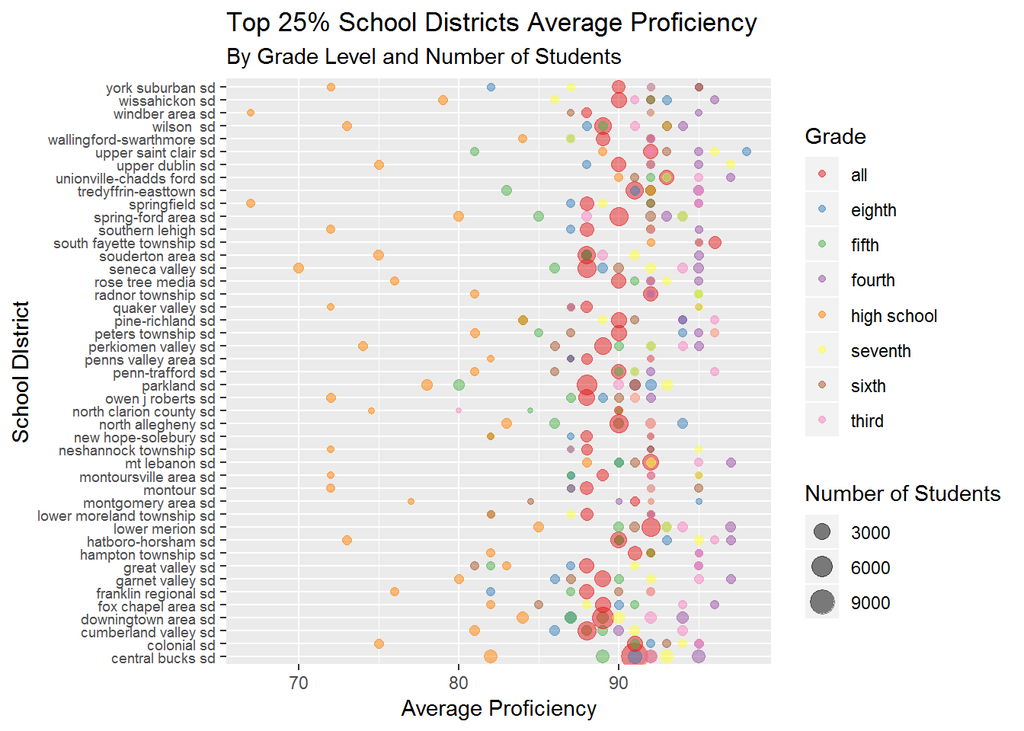

### Description One

There doesn’t appear to be many patterns here. The high school scores are some of the lowest and we see some grouping of fourth grade around the 95 percentile. I used this because if a school has a high overall score, perhaps it can be related to the number of students in their district.

### Plot Two

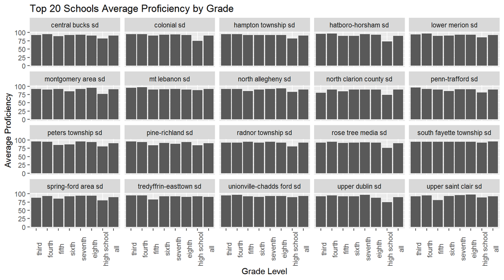

### Description Two

The averages across all grades in these top districts are fairly consistent. We do see the drop off in scores in the high school grade levels for most of the districts. I wanted to see the top schools and whether they were consistent throughout each grade level. It does not appear that one grade level is skewing any others. This can be for a number of reasons, like hiring good teachers, calibrating teachers on what’s being taught, or a large emphasis on taking (and studying for) assessment tests.

### Plot Three

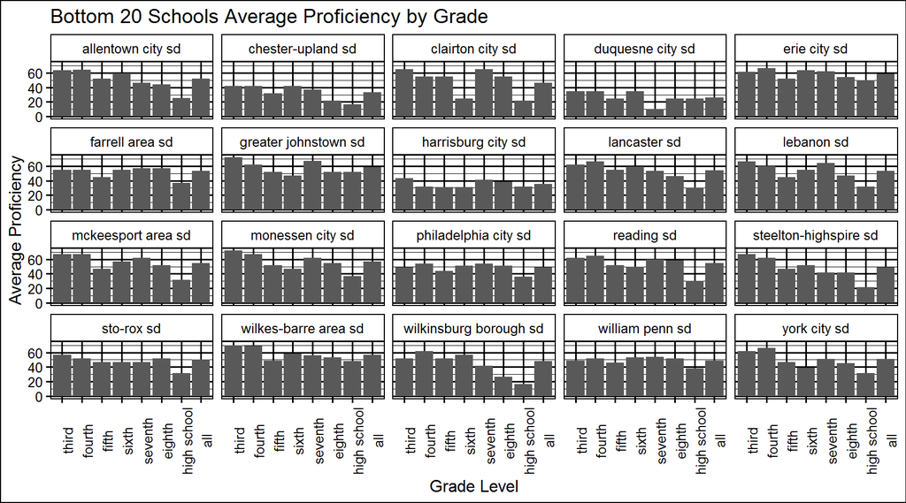

### Description Three

The bottom schools do not have much consistency across grade levels with a few exceptions. Wilkinsburg Borough has a very poor proficiency for high school. If the top schools were consistent, I wondered if the bottom schools would show any consistency. The scores here fluctuate from grade to grade, most of which remains below a passing level.

# Reflection

The scores within a school district are often less consistent across grade levels than I originally anticipated. As someone who grew up in Pennsylvania, it is a bit disheartening to see how poor some of our school districts are in mathematics.

There was a lot of reshaping and cleaning that needed to be done for this dataset. I stumbled on the two applications of gather() as well as figuring out how to separate a field if I was only interested in one of the returned values.

Future work with this dataset can look at some other information such as taxes. It would be interesting to see how each school district performs in relation to how much school tax they collect. This would help us see what the residents get for their hard earned money. We may be able to look at census data as well for median household income to see if that plays a role. Information on Facebook would be very interesting if paired with this data. For example, we could look at current professions and see what the graduates of these schools are doing. Would we see more STEM professions from the top districts? What about secondary education? How many of the graduates go on to secondary education from the top schools versus the bottom schools?